# P7

Luis Domínguez

2024-05-09

# Práctica 7

En esta práctica continuamos usando el archivo `prac6.csv` que se encuentra en el aula virtual.

```r
Xt <- read_csv("./prac6b.csv")
Xt <- as.ts(Xt)
```

## 1. Para el mejor modelo de acuerdo a AIC de la práctica 6:

1. Determina la significancia de los coeficientes estimados.

```r
modelo<-arima(Xt,order=c(3,0,1))
summary(modelo)
```

```
##
## Call:
## arima(x = Xt, order = c(3, 0, 1))
##
## Coefficients:
##          ar1     ar2     ar3     ma1  intercept
##       0.1762  0.1111  0.1080  0.6305     0.0176
## s.e.  0.0784  0.0689  0.0407  0.0744     0.0852
##
## sigma^2 estimated as 1.002:  log likelihood = -1420.58,  aic = 2853.16
##
## Training set error measures:
##                         ME     RMSE       MAE      MPE     MAPE      MASE
## Training set -0.0001673722 1.001241 0.8090632 37.42528 191.7465 0.8604493
##                    ACF1
## Training set 0.00148459
```

2. Calcula los intervalos de confianza para los estimadores:

```r
confint(modelo)
```

```
##                 2.5 %    97.5 %
## ar1        0.02254658 0.3298042
## ar2       -0.02385379 0.2460558
## ar3        0.02822871 0.1877640
## ma1        0.48459253 0.7763628
## intercept -0.14943418 0.1846737
```

3. Grafica los residuos de este modelo:

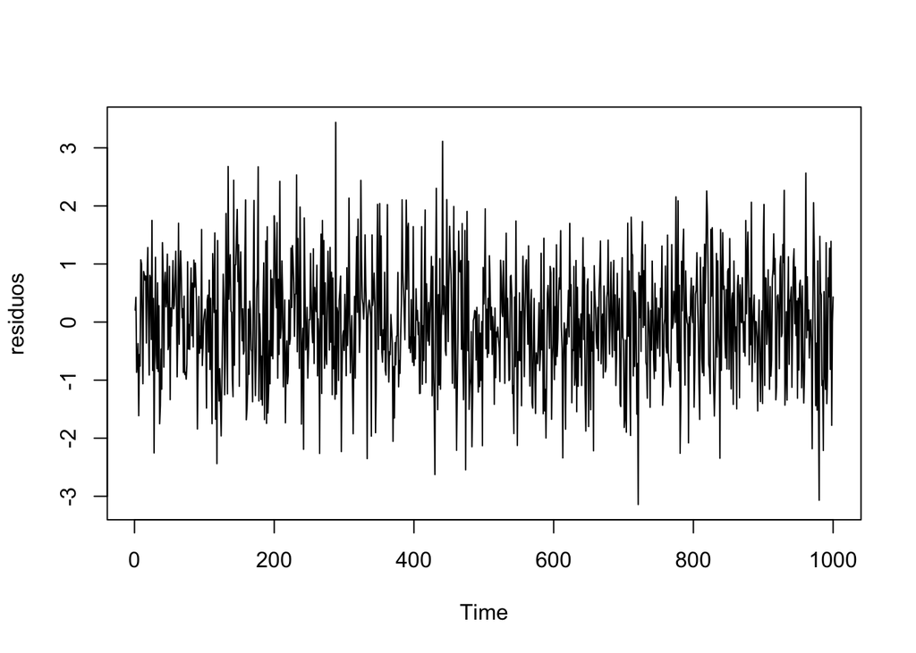

```r
residuos <- resid(modelo)
plot(residuos)
```

4. Grafica la ACF para los residuos de este modelo.

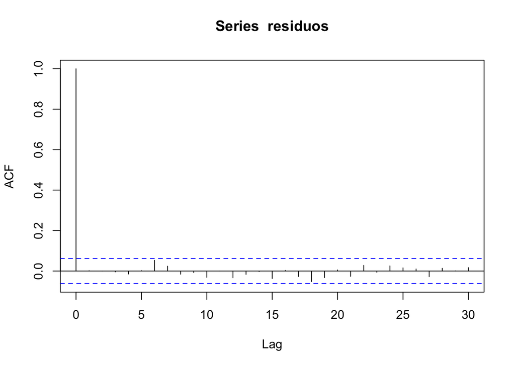

```r
acf(residuos)
```

5. Realiza la prueba de Ljung-Box para los residuos del modelo. Concluye si los residuos del modelo son ruido blanco o no. Utiliza la función:

```r
Box.test(resid(modelo), lag = 20, type = "Ljung-Box")
```

```
##
##  Box-Ljung test
##
## data:  resid(modelo)
## X-squared = 12.429, df = 20, p-value = 0.9005
```

## 2. Un modelo que no elimina la autocorrelación

Supongamos el ajuste de un modelo incorrecto, ARIMA(1,0,1) para Xt. En esta sección, “ajuste2” es la variable que contiene la información del ajuste hecho por R,

```r
ajuste2 <- arima(Xt, order = c(1, 0, 1))
```

1. Determina la significancia de los coeficientes estimados para el mejor candidato de acuerdo a AIC.

```r
summary(ajuste2)
```

```
##
## Call:
## arima(x = Xt, order = c(1, 0, 1))
##
## Coefficients:
##          ar1     ma1  intercept
##       0.2858  0.5526     0.0177
## s.e.  0.0467  0.0449     0.0697
##
## sigma^2 estimated as 1.029:  log likelihood = -1433.44,  aic = 2874.88
##
## Training set error measures:
##                         ME    RMSE       MAE      MPE     MAPE      MASE
## Training set -1.026793e-05 1.01423 0.8182806 35.24324 195.0769 0.8702521
##                    ACF1
## Training set -0.0233185
```

2. Calcula los intervalos de confianza para los estimadores:

```r
confint(ajuste2)
```

```
##                2.5 %    97.5 %
## ar1        0.1942177 0.3773120
## ma1        0.4645576 0.6405441
## intercept -0.1188875 0.1541934
```

3. Grafica los residuos de este modelo:

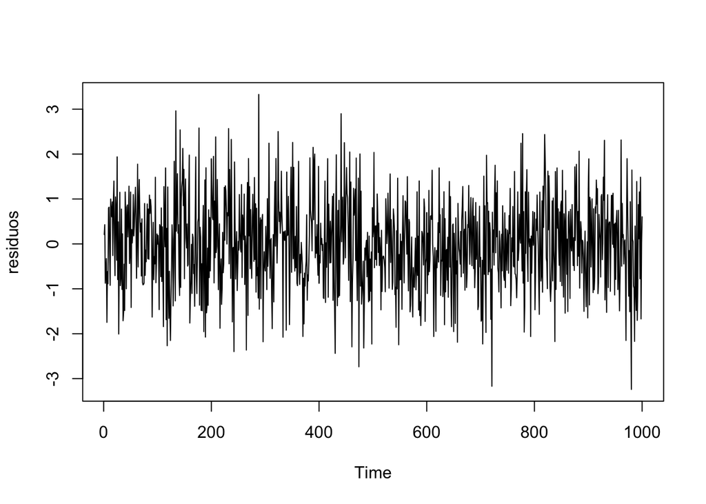

```r
residuos <- resid(ajuste2)
plot(residuos)
```

4. Grafica la ACF para los residuos de este modelo

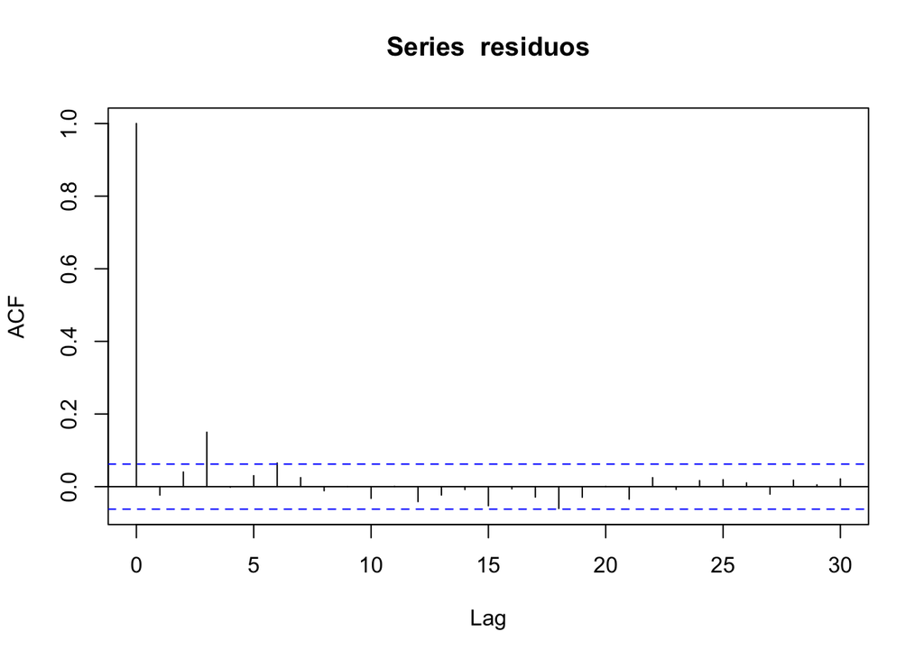

```r
acf(residuos)
```

5. Realiza la prueba de Ljung-Box para los residuos del modelo. Concluye si los residuos del modelo son ruido blanco o no. Utiliza la función:

```r
Box.test(resid(ajuste2), lag = 20, type = "Ljung-Box")
```

```
##
##  Box-Ljung test
##
## data:  resid(ajuste2)
## X-squared = 42.355, df = 20, p-value = 0.002485
```

Por lo tanto, los residuos de nuestro modelo no son ruido blanco, al p ser menor a 0.05, con base en la hipótesis nula.